# Supplement_Analysis_Prep_GUS

Eileen Xu

2024-04-29

## Coding youth-report SDQ, CIDI and GAD-7 at sweep 10

SDQ - 25 questions, starts with “CjSDQ”

CIDI - 13 questions, starts with “CjCid”

GAD-7 - 7 questions, starts with “CjGad”

### Code youth-reported SDQ subscale scores:

Following GUS procedures for calculating each subscale. Scores are prorated so that participants who answered at least 3/5 questions for the subscale can be included. Take the mean value for each subscale question and multiply by 5. Then round to the next integer.

Values <0 are missing.

### Coding CIDI and GAD-7

Code CIDI - in GUS the responses are coded as (1) Yes, (2) No

Since the secondary symptoms were only asked if participants answered “Yes” to the first question “Have you ever in your life had a period lasting several days or longer when most of the day you felt depressed, or when you lost interest in most things you usually enjoy like school and hobbies?”, secondary symptoms totalling 4 or more count as a depression case.

CjCidDp - Ever had several days or longer when most of the day you felt depressed/lost interest in things you usually enjoy?

CjCidWp - Did this start within two months of the death of someone close or after a stressful/traumatic event?

CjCidFl - How much of the day did these feelings usually last? (1) All day (2) Most of the day (3) Half of the day (4) Less than half of the day

CjCidDa - Did you feel this way… (1) Every day (2) Almost every day (3) Less often

CjCidLe - Did you feel more tired or low on energy than is usual for you?

CjCidWe - Did you gain or lose weight without trying, or did you stay about the same weight? (1) Gained weight (2) Lost weight (3) Both gained and lost some weight (4) Stayed about the same or was on a diet

CjCidSc - Did your sleep change?

CjCidCo - Did you have a lot more trouble concentrating than usual?

CjCidDo - People sometimes feel down on themselves, no good, worthless. Did you feel this way?

CjCidDt - Did you think a lot about death - either your own, someone else’s or death in general?

Before calculating CIDI diagnoses I have to change coding to 0 = no, 1 = yes. For the weight change question, do I include “both gained and lost some weight” as a yes to the weight symptom? It’s excluded currently.

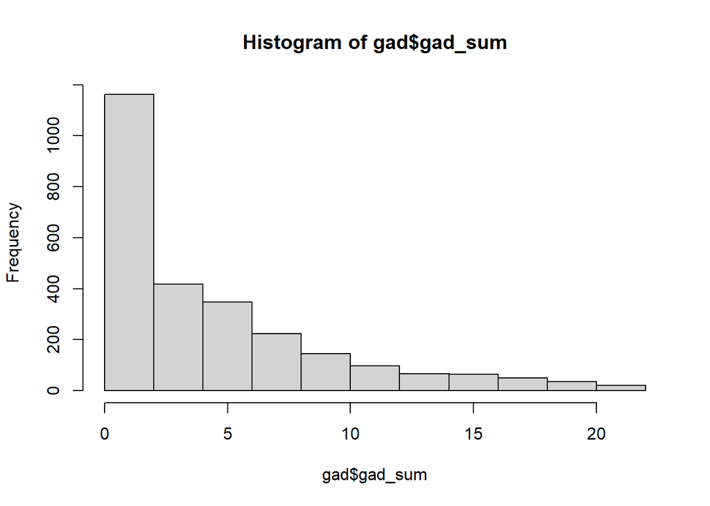

| N | 2943.00 |
| --- | --- |
| Emot_M | 3.36 |
| Emot_SD | 2.58 |
| Conduct_M | 1.80 |
| Conduct_SD | 1.63 |
| Hyper_M | 3.73 |
| Hyper_SD | 2.39 |
| Peer_M | 1.88 |
| Peer_SD | 1.74 |
| CIDI_dep | 151.00 |
| CIDI_perc | 5.73 |
| GAD_M | 4.68 |
| GAD_sd | 4.93 |
| GAD_none | 1766.00 |
| GAD_mild | 528.00 |
| GAD_moderate | 197.00 |
| GAD_severe | 138.00 |

## Teacher-reported SDQ in primary 6 (sweep 8)